# wbstats

# Introduction

A package for accessing data via the World Bank’s *API* (application programming interface) is [wbstats](https://cran.r-project.org/web/packages/wbstats/wbstats.pdf).

This can actually give you cleaner data faster; the alternative is downloading indicators one by one and then cleaning and merging all the indicator data. With the wbstats package you can request a number of indicators at once, and also ask for rather detailed description about the source of the indicator.

Note: Another API to the World Bank website is WDI.

# We load wbstats and the tidyverse

```r
library(wbstats)
library(tidyverse)
```

# Go to data.worldbank.org for indicators of interest

Once you navigate to an indicator of interest, you will see its ID code in the web address (URL).

An example is **AG.LND.AGRI.ZS**. It is very specific, but also difficult for a human to just understand. Search google for this indicator ID. What does the indicator capture?

> your answer

# Requesting data

# Searching indicators

Another way of searching for indicators is using the wbsearch() `function`.

```r
wbsearch("population growth")
wbsearch("food")
```

How many items are returned in the search for “Population growth”

How many for “food”?

# We can get detailed information about our indicators with the `wbindicators` function.

```r
# requesting data on all the indicators, in English
wbindicators(lang = "en") %>%
  # narrow to only cases where indicatorID
  # is among (%in%) my_indicators
  filter(indicatorID %in% my_indicators) ->
meta_data_wb_indicators
```

# Indicator short description

We can “pull” the short description for the indicators. Just execute the code below.

```r
# short description.
meta_data_wb_indicators %>%
  pull(indicator)
```

```
## [1] "Agricultural land (% of land area)"
## [2] "GDP per capita, PPP (current international $)"
## [3] "Population growth (annual %)"
```

What are the three short names?

# More complete description

Or we can “pull” the full description.

```r
# long description
meta_data_wb_indicators %>%
  pull(indicatorDesc)
```

```
## [1] "Agricultural land refers to the share of land area that is arable, under permanent crops, and under permanent pastures. Arable land includes land defined by the FAO as land under temporary crops (double-cropped areas are counted once), temporary meadows for mowing or for pasture, land under …
## [2] "GDP per capita based on purchasing power parity (PPP). PPP GDP is gross domestic product converted to international dollars using purchasing power parity rates. An international dollar has the same purchasing power over GDP as the U.S. dollar has in the United States. GDP at purchaser's pric…
## [3] "Annual population growth rate for year t is the exponential rate of growth of midyear population from year t-1 to t, expressed as a percentage . Population is based on the de facto definition of population, which counts all residents regardless of legal status or citizenship."
```

# inspired wbstats

Well just getting the data is a little uninspiring. Let’s look at an example where we actually do something fun with them — like create the “Hans Rosling Gapminder animation”. https://www.youtube.com/watch?v=jbkSRLYSojo

You may have used the gapminder package. The gapminder dataset in that package only contains every 5th year, but if you prefer to have data for every year, using the wbstats package is a good option.

# change over time and animation

First, let’s just use the gapminder data. Look at the following plot. It shows a picture of evolution, but it is not animated.

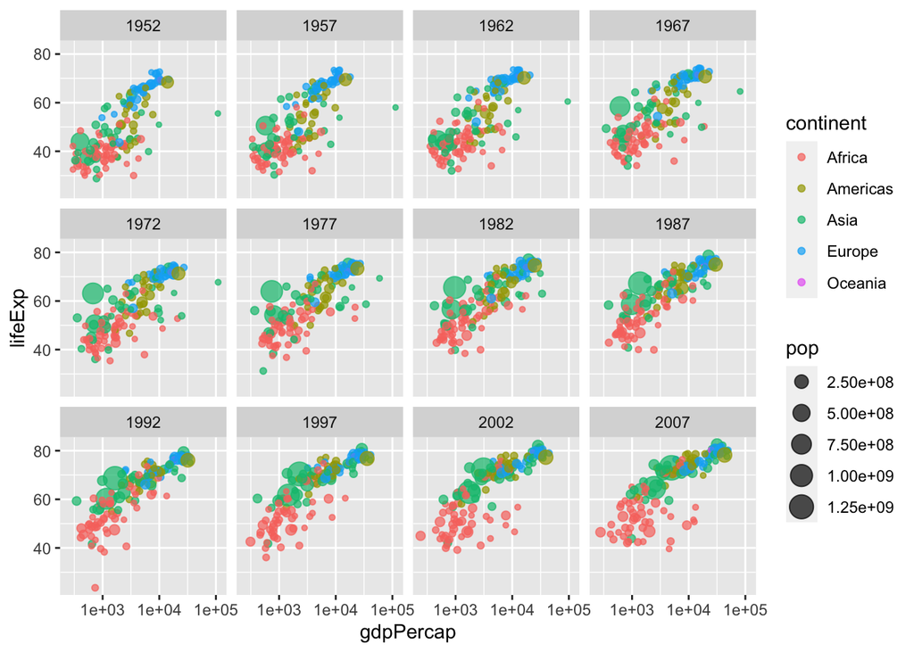

```r
library(gganimate)
library(gapminder)

ggplot(gapminder) +
  aes(x = gdpPercap) +
  aes(y = lifeExp) +
  aes(size = pop) +
  aes(colour = continent) +
  geom_point(alpha = 0.7) +
  scale_x_log10() +
  facet_wrap(~year)
```

Now, use the plot above as a basis. *Delete the facet_wrap() statement*, and instead try your hand at animation. Work with your group. What statements need to be added? https://gganimate.com/